# The Work-Injury Introduction and Expansion Dataset

### Nate Breznau, breznau.nate@gmail.com

## Abstract

This workflow brings together various country-time indicators to construct a dataframe for us in the analysis. Many sources are theoretically relevant in the introduction and expansion of work-injury policy. These data are a combination of information about economic development, work-injury policy, the legal end of slavery and forced labor and democratization.

## Setup

### GWIP

The Global Work-Injury Policy Data.

*gwip_v1.csv* ([Breznau and Lanver 2020](https://dataverse.harvard.edu/dataset.xhtml?persistentId=doi:10.7910/DVN/IVKYIE))

### Independent Nation States

We aim to measure when geographic territories, peoples or empires became independent nation states. This is important for several reasons. The primary reason is that social policy - what we understand as welfare state development - was only implemented by nation states. By definition a welfare state requires a national state governance. The second reason is that prior to nation states and internationally recognized borders, geographies shifted immensely. China, Germany, Poland and France for example included dramatically different geographic spaces during their empire(s).

The modern nation state arguably starts in Europe, possibly with the French Revolution. However, the wartime shifting borders and constant overthrowing of various powers during the prior to the early 19th century means coding ‘national independence’ during this period is misleading. Therefore our national independence variable has most European countries coded as 1816 (e.g., Germany and France) or later. The US is the oldest in the data with 1783 and China is much ‘younger’ with 1860 as this marked the moment when international conflicts pushed China into a reactive (and smaller) national policy. These measures are not intended to reflect prevailing historical narratives, rather to trace the orgins of nation states and their geographies as we know them today.

### GDP per capita

*mpd2018.csv* [Maddison 2018 version](http://www.ggdc.net/maddison/maddison-project/home.htm). (Bolt, Inklaar, de Jong and Luiten van Zanden 2018)

The goal is to have a variable that compares economic development (a proxy for industrialization, measured as GDP per capita) in 1900. In hindsight not ideal, but I simply added missing values to the Excel sheet rather than automate this.

#### 1. Setup Frame

To account for missing data the following changes were made to the file *mpd2018.xlsx*

Included missing cells to complete time series for all countries (adjusted xlsx file, just added year rows)

This was then saved as *mpd2018i.xlsx*

#### 2. Missing Countries: GDP interpolations

##### Imputation via similar cases

Although not perfect, missing data can be imputed using similar cases.

| Target Country | Interpolation Case |
| --- | --- |
| *Bhutan* | Sri Lanka |
| *Belize* | Jamaica |
| *Liechtenstein* | Luxembourg |
| *Monaco* | Luxembourg |
| *South Sudan* | Sudan |
| *San Marino* | Austria |
| *Andorra* | Austria |

##### Lower GDP Islands, mostly S.E. Asia/Pacific

| Target Country | Interpolation Case | Notes |
| --- | --- | --- |
| *Suriname* | St. Lucia | 1 for 1900 (adj for crash after 2013) |
| *Solomon Islands* | Cambodia |  |
| *Fiji, Guyana, Samoa, Marshall Islands, Palau, Micronesia, Vanuatu* | Indonesia (to 1950) | then 500 for 1900 |
| *Kiribati* | Myanmar | (start at 500) |

###### Goggle Data Query

[interactive chart not shown]

##### Low/Mid GDP Islands, mostly Latin America/Carribean

[output not shown]

##### Google Data Query

[interactive chart not shown]

#### 3. Partially Incomplete Time-Series

For countries with GDP data that does not go all the way back to 1900, I interpolate 1900 and the linearly fill from this interpolation up to the earliest possible observation.

##### Interpolate 1900 = 1

*Burundi*, *Gambia*, *Guinea*, *Guinea-Bissau*, *Equit. Guinea*, *Niger*, *Angola*, *Central Afr. Rep.*, *Cameroon*, *Comoros*, *Kenya*, *Mozambique*, *Rwanda* *Mauritania*, *Somalia* (The diff. btw. above and below categories has to do with time-series-interpolation over historical accuracy)

##### Interpolate 1900 = 500

*Albania*, *Benin*, *Burkina Faso*, *Botswana*, *D.R. Congo*, *Congo*, *Cabo Verde*, *Cambodia*, *Djibuti*, *Dominica Namibia*, *Senegal*, *Sudan*, *Togo*, *Chad*, *Ethiopia*, *Gabon*, *Laos*, *St. Lucia*, *Liberia*, *Thailand*, *Taiwan*, *Uganda*, *Madagascar*, *Mali*, *Malta*, *Mongolia*, *Mauritius*, *Malawi*, *Nigeria*, *Sierra Leone*, *Sao Tome*, *Seychelles*, *Tanzania*, *Ukraine*, *Yemen*, *Zambia*, *Zimbabwe*

##### Other Interpolations

| Target Country | Unique Interpolation |
| --- | --- |
| *Somalia* | 2016 = 1700 |
| *Trinidad and Tobago*, *Afghanistan*, *Bangladesh*, *Bahrain*, | *Cyprus*,*Lybia*, *Oman*,*Pakistan* |
| *UAE* | 1950 = 500 |
| *UAE* | 1958 (discovered oil)= 3000 |
| *UAE* | 1960 (oil) = 20000 |
| *Qatar* | 1938 = 500 |
| *Qatar* | 1940 (discovered oil)= 2000 |
| *Qatar* | 1943 (oil) = 10000 |
| *Kuwait* | 1900 = 500 |
| *Kuwait* | 1938 (discovered oil) = 2000 |
| *Kuwait* | 1940 (oil) = 6000 |
| *Kuwait* | 1950 = 9000 |
| *Nicaragua*, *Paraguay*, *El Salvador* | 1850 = 1 |
| *Guatemala*, *Honduras*, *Haiti*, *Hungary*, *Korea*, *Myanmar*, | *Puerto Rico*, *Romania* |
| *Singapore* | 1850 = 900 |
| *Malaysia* | 1850 = 1000 |
| *New Zealand* | 1840 = 1000 |
| *Panama* | 1850 = 1000 |
| *Russia* | 1850 = 1500 |
| *Barbados* | 1890 = 500 |
| *Iceland* | 1890 = 1000 |
| *Ivory Coast* | 1900 = 1200 |
| *Algeria* | 1870 = 900 |
| *Algeria* | 1900 = 1000 |
| *Algeria* | 1920 = 3500 |
| *Algeria* | 1950 = 6000 |
| *Estonia* & *Kazakhstan* | (1946 = 4700) |
| *Kyrgystan*, *Latvia*, *Lithuania*, *Tajikistan*, *Turkmenistan* | 1950 = 5000 |
| *Uzbekistan* | 1950 = 3000 |
| *Moldova* | 1950 = 1000 |
| *Israel* | 1940 = 3500 (trend) |
| *Luxembourg* | 1900 = 5000 & 1890 = 3000 |

#### 4. Russian Territories & USSR

Russian territories 1890-1949 (take USSR GDP) *Estonia*, *Latvia* & *Lithuania*

Russian territories 1890-1930 (take USSR GDP) *Kyrgyzstan*, *Croatia*, *Slovenia*,

Russian USSR ‘Territories’ as of 1922 (use USSR 1900+GDP for predictive purposes)

*Belarus*, *Ukraine*, and TransCaucasia (*Armenia*, *Azerbaijan*, *Georgia*) (USSR GDP until 1958 to give a transition until 1973, 1st year available in Maddison)

Final data saved as *mpd2018.csv*

#### 5. Import and Clean

#### 6. Merge GWIP & GDP

### Legal Slavery & Forced LLabor

Ola Rosling, Gapminder.org, gapm.io/d_lslave_v1

https://www.gapminder.org/data/documentation/legal-slavery/ file downloaded 24-04-2020 Data countries by year sheet saved as a .csv file *data_legal_slavery_country.csv*

```r
abolish <- read.csv(here::here("data", "data_legal_slavery_country.csv"), header=T, check.names=F, stringsAsFactors = F)

abolish_long <- abolish

#convert strings to years
illegal <- which(abolish=="Illegal", arr.ind=T)
legal <- which(abolish=="Legal", arr.ind=T)
abolish[illegal]<-colnames(abolish)[illegal[,2]]
#use the number 3000 to make sure it does not conflict in the row minimum calculation
abolish[legal]<-3000

abolish[4:221] <- as.numeric(unlist(abolish[4:221]))

#rowmin = year of abolition
abolish$abol <- apply(abolish[,4:221], 1, FUN=min)
abolish$cow_code <- countrycode(abolish$name, "country.name", "cown")
abolish$cow_code <- ifelse(abolish$name=="Serbia", 345, abolish$cow_code)

abolish <- completeFun(abolish, "cow_code")

abolish <- select(abolish, cow_code, abol)

wi_df <- left_join(wi_df, abolish, by = "cow_code")

# Saudi Arabia missing
wi_df <- wi_df %>%
  mutate(abol = ifelse(cow_code==670, 1962, abol))

# Almost all countries had slavery prior to capitalism. This is about chattel and profit-extraction/excess produciton slavery. Code slavery in a way that countries = 1 if they used slave/forced labor for industrial, colonial and capitalist production, or if they were a major source for the slaves used in this production (=1). Arabic peoples were major slave traders but were not major producers nor the source of slaves (so = 0)

#Long format
abolish_long[illegal] <- 0
abolish_long[legal] <- 1
abolish_long$cow_code <- countrycode(abolish_long$name, "country.name", "cown")
abolish_long$cow_code <- ifelse(abolish_long$name=="Serbia", 345, abolish_long$cow_code)
abolish_long <- abolish_long[,4:222]


abol_long <- reshape(abolish_long, direction = "long", idvar = "cow_code", v.names = "slavery", timevar = "year", times = 1800:2017, varying = list(names(abolish_long)[1:218]))

yes <- c(2,135,165,651,670,698,900)

no <- c(20,155,344,349,352,366,367,368,371,372,373,616,620,630,640,645,652,660,663,645,679,690,692,694,696,703,760,771,775,780,811,812,817,820,830,835,840,850,920, 200, 205, 210, 211, 212, 220, 221, 223, 225, 230, 235, 255, 290, 305, 310, 316, 317, 325, 338, 339, 345, 350, 355, 359, 360, 365, 369, 370, 375, 380, 385, 390, 395, 666, 698, 700, 701, 702, 704, 705, 710, 712, 731, 732, 740, 750, 770, 800, 817, 940, 950, 983, 986, 987)

wi_cnts <- abolish

wi_cnts <- wi_cnts %>%
  mutate(slavery = ifelse(is.na(abol),0,1),
         slavery = ifelse(cow_code %in% yes,1,slavery),
         slavery = ifelse(cow_code %in% no,0,slavery))
# Puerto Rico missing, code 1873
wi_cnts[nrow(wi_cnts)+1,] <- c(6,1873,1)
```

### Colonial Rule

QoQ Basic Data *qog_bas_cs_jan20.csv* ([Dahlberg et al. 2020](http://www.qog.pol.gu.se%20doi:10.18157/qogbasjan20))

Variable Description: This is a tenfold classification of the former colonial ruler of the country. We have excluded the British settler colonies (the US, Canada, Australia, Israel and New Zealand), and exclusively focused on Western overseas’ colonialism. This implies that only Western colonizers (e.g. excluding Japanese colonialism), and only countries located in the non-Western hemisphere ‘overseas’ (e.g. excluding Ireland & Malta), have been coded. Each country that has been colonized since 1700 is coded. In cases of several colonial powers, the last one is counted, if it lasted for 10 years or longer. The categories are the following:

0. Never colonized by a Western overseas colonial power
1. Dutch
2. Spanish
3. Italian
4. US
5. British
6. French
7. Portuguese
8. Belgian
9. British-French
10. Australian

I add Russia as a colonizer (prior to 1922)

11. Russia

```r
colony <- read.csv(here::here("data", "qog_bas_cs_jan20.csv"), header=T, stringsAsFactors = F)

colony$cow_code <- colony$ccodecow

colony <- select(colony, cow_code, ht_colonial)

# Estonia, Latvia and Lithuania were Russian 'colonies' as territories (from 1710) prior to 1918; Kyrgyzstan, Croatia and Slovenia 'territories'; code Transcaucasia (Armenia, Azerbaijan & Georgia) as 'colonies' as they were subject to USSR law once formed;
colony$ht_colonial <- ifelse(colony$cow_code == 366 | colony$cow_code == 367 | colony$cow_code == 368 | colony$cow_code == 371 | colony$cow_code == 372 | colony$cow_code == 373 | colony$cow_code == 703 | colony$cow_code == 344 | colony$cow_code == 355 | colony$cow_code == 370 | colony$cow_code == 359 | colony$cow_code == 349,11,colony$ht_colonial)

wi_df <- left_join(wi_df,colony,by="cow_code")

# code NA as not colonial for now, check later
wi_df$ht_colonial <- ifelse(is.na(wi_df$ht_colonial),0,wi_df$ht_colonial)

# make colonial dummy
wi_df$fcolony <- ifelse(wi_df$ht_colonial==0,0,1)
```

Merge new additions

```r
# get all data together so far

# remove duplicate abol
wi_df <- select(wi_df, -c(abol))
wi_df <- left_join(wi_df,wi_cnts, by = c("cow_code"))


# fix colonial data
wi_df <- wi_df %>%
  mutate(ht_colonial = ifelse(cow_code==817,6,ht_colonial),
         ht_colonial = ifelse(cow_code==6,2,ht_colonial),
         ht_colonial = ifelse(is.na(ht_colonial),0,ht_colonial))


# make colonial dummy
wi_df$fcolony <- ifelse(wi_df$ht_colonial==0,0,1)
```

### Polity IV (Democratization)

*PolityData.rds* ([Polity IV scores](http://www.systemicpeace.org/)) Saved as this file to preserve replicability (as Polity scores get updated regularly)

#### Import/Clean

```r
# Last retreived 07-Apr-2020
# saved in case of version changes, see "A02 Data Compile Polity IV.R"
PolityData <- readRDS(here::here("data", "PolityData.rds"))

# fix Germany & Vietnam
PolityData$cow_code <- ifelse(PolityData$cow_code==260,255,PolityData$cow_code)
PolityData$cow_code <- ifelse(PolityData$cow_code==816,817,PolityData$cow_code)

# Introduce longitudinal data
wi_df_long <- select(wi_df, -c(gdpi, gdp_7yr_rate, gdp_7yr_a))
wi_df_long <- left_join(gdpm, wi_df_long, by = c("cow_code"))

# set up time-series data
wi_df_long <- wi_df_long %>%
  mutate(indep = 1,
         firstlaw = 1,
         firstrisk = 1,
         firstsocins = 1,
         bluefull = 1)
wi_df_long <- wi_df_long %>%
  group_by(cow_code) %>%
  mutate(indep = ifelse(year < independence,0,indep),
         firstlaw = ifelse(year < labor_workinjury_firstlaw,0,firstlaw),
         firstrisk = ifelse(year < labor_workinjury_firstins,0,firstrisk),
         firstsocins = ifelse(year < labor_workinjury_first_socins, 0, firstsocins),
         bluefull = ifelse(year < labor_workinjury_firstlaw_bluecollar_fullcoverage,0,bluefull))

wi_df_long <- left_join(wi_df_long,PolityData, by = c("cow_code","year"))

#clean up
wi_df_long <- select(wi_df_long, -c(iso2c,standardized_country,ccode,scode))

# make colonial rule a form of authoritarian governance
# some cases not coded properly for fcolony
# interpolate polityIV
wi_df_long <- wi_df_long %>%
  group_by(cow_code) %>%
  mutate(fcolony = max(fcolony),
         polity2i = ifelse(year <= independence & fcolony == 1 & is.na(polity2),-10,polity2),
         polity2i = na.approx(polity2i, maxgap=15, rule = 2)) %>%
  ungroup()

wi_df_long$polity2i <- round(wi_df_long$polity2i, 0)

wi_df_long <- select(wi_df_long, cow_code, country.x, year, polity2, polity2i, gdpi, independence, everything())

rm(gdpm, gdpi,abol_long,illegal, legal,colony)

wi_df_long <- select(wi_df_long, fcolony, everything())
```

#### Missing

##### Freedom House after indep, 2019 interpolation

| COW Code | Name | Interpolated Score | Freedom House Score |
| --- | --- | --- | --- |
| 31 | Bahamas | 8 | (9/10) |
| 53 | Barbados | 9 | (9.5/10) |
| 54 | Dominica | 8 | (9/10) |
| 55 | Grenada | 8 | (9/10) |
| 56 | St Lucia | 8 | (9/10) |
| 57 | St Vincent | 8 | (9/10) |
| 58 | Antigua | 7 | (8.5/10) |
| 60 | St Kitts | 8 | (9/10) |
| 80 | Belize | 7 | (8.5/10) |
| 346 | Bosnia & H. | 0 | (5/10) |
| 403 | Sao Tome | 6 | (8/10) |
| 591 | Seychelle | 4 | (7/10) |
| 835 | Brunei | -4 | (3/10) |
| 935 | Vanuatu | 6 | (8/10) |
| 946 | Kiribati | 8 | (9/10) |
| 983 | Marshall Is | 8 | (9/10) |
| 987 | Micronesia | 8 | (9/10) |
| 990 | Samoa | 6 |  |

##### Other Missing

[output not shown]

##### British rule where Europeans took over

Score 2 prior to indep

20 Canada 660 Lebanon - somewhere in between - code 0 prior to 1943 (maybe remove fcolony=1?) 900 Australia

##### Parts of Yugoslavia

(recode 1918-2005)

341 Montenegro

##### Parts of the USSR

use Russian scores 1922-1990 (all) 1918-1921 (only if missing)

316 Czech Rep, 343 Macedonia, 359 Moldova, 366 Estonia, 367 Latvia, 368 Lithuania, 369 Ukraine take Russia for all missing, 370 Belarus, 372 Georgia, 373 Azerbaijan, 701 Turkmenistan, 702 Tajikistan, 703 Kyrgyzstan (make sure to replace imputed values!), 704 Uzbekistan, 705 Kazakhstan

##### Add Scores

```r
# Use case_when in the future
wi_df_long <- wi_df_long %>%
  mutate(polity2i = ifelse(cow_code==31 & is.na(polity2i), 8, polity2i),
  polity2i = ifelse(cow_code==53 & is.na(polity2i), 9, polity2i),
  polity2i = ifelse(cow_code==54 & is.na(polity2i), 8, polity2i),
  polity2i = ifelse(cow_code==55 & is.na(polity2i), 8, polity2i),
  polity2i = ifelse(cow_code==56 & is.na(polity2i), 8, polity2i),
  polity2i = ifelse(cow_code==57 & is.na(polity2i), 8, polity2i),
  polity2i = ifelse(cow_code==58 & is.na(polity2i), 7, polity2i),
  polity2i = ifelse(cow_code==60 & is.na(polity2i), 8, polity2i),
  polity2i = ifelse(cow_code==80 & is.na(polity2i), 7, polity2i),
  polity2i = ifelse(cow_code==346 & is.na(polity2i), 0, polity2i),
  polity2i = ifelse(cow_code==403 & is.na(polity2i), 6, polity2i),
  polity2i = ifelse(cow_code==591 & is.na(polity2i), 4, polity2i),
  polity2i = ifelse(cow_code==835 & is.na(polity2i), -4, polity2i),
  polity2i = ifelse(cow_code==935 & is.na(polity2i), 6, polity2i),
  polity2i = ifelse(cow_code==946 & is.na(polity2i), 8, polity2i),
  polity2i = ifelse(cow_code==983 & is.na(polity2i), 8, polity2i),
  polity2i = ifelse(cow_code==987 & is.na(polity2i), 8, polity2i),
  polity2i = ifelse(cow_code==990 & is.na(polity2i), 6, polity2i),
  polity2i = ifelse(cow_code==115, na.approx(polity2i,maxgap=Inf), polity2i),
  polity2i = ifelse(cow_code==255 & year<1869,-6,polity2i),
  polity2i = ifelse(cow_code==290 & year<1918 & year >1900,-10,polity2i),
  polity2i = ifelse(cow_code==338 & year > 1945,8,polity2i),
  polity2i = ifelse(cow_code==338 & year < 1946,0,polity2i),
  polity2i = ifelse(cow_code==712 & year < 1924,-7,polity2i),
  polity2i = ifelse(cow_code==339 & year < 1914,-10,polity2i),
  polity2i = ifelse(cow_code==731 & year > 1900 & year<1948,-10,polity2i),
  polity2i = ifelse(cow_code==732 & year < 1948,-10,polity2i),
  polity2i = ifelse(cow_code==670 & year < 1926,-10,polity2i),
  polity2i = ifelse(cow_code==713 & year < 1949 & year > 1929,-8,polity2i),
  polity2i = ifelse(cow_code==817 & is.na(polity2i),-10,polity2i),
  polity2i = ifelse(cow_code==20 & year < 1867,2,polity2i),
  polity2i = ifelse(cow_code==660 & year < 1943,0,polity2i),
  polity2i = ifelse(cow_code==900 & year < 1901,2,polity2i),
  polity2i = ifelse(cow_code==355 & year < 1879,-4,polity2i),
  polity2i = ifelse(cow_code==365 & year > 1940 & year < 1948,-10,polity2i))


wi_df_long <- wi_df_long %>%
  mutate(polity2i = ifelse(cow_code == 6 & year > 1899 & year < 1917, -8, ifelse(cow_code == 6 & year > 1916 & year < 1943, -6, ifelse(cow_code == 6 & year > 1942 & year < 1952, 2, ifelse(cow_code == 6 & year > 1951, 6, polity2i)))), #Puerto Rico
         polity2i = ifelse(cow_code == 986 & year < 1947, -10, ifelse(cow_code == 986 & year > 1946 & year < 1994, 4, ifelse(cow_code == 986 & year > 1993, 8, polity2i))), # Palau
         polity2i = ifelse(cow_code == 713 & year < 1949,-10, ifelse(cow_code == 713 & year > 1948, 8, polity2i))) # Taiwan



wi_df_longx <- wi_df_long
wi_df_longx$polity2ii <- wi_df_longx$polity2i
wi_df_longx <- select(wi_df_longx,cow_code, year, polity2ii)

# fix Montenegro
wi_m_341 <- subset(wi_df_longx, cow_code==345 & year<2007)
wi_m_341$cow_code <- 341

# fix Czech/Slovak - Austro-Hungary
wi_m_316a <- subset(wi_df_longx, cow_code==305 & year<1918)
wi_m_316a$cow_code <- 316
wi_m_317a <- subset(wi_df_longx, cow_code==305 & year<1918)
wi_m_317a$cow_code <- 317

# Russian/Soviet entities
wi_df_long_R <- subset(wi_df_longx, cow_code==365 & year<1991)

wi_m_375 <- subset(wi_df_long_R, year<1917)
wi_m_375$cow_code <- 375

wi_m_316 <- subset(wi_df_long_R, year>1917)
wi_m_316$cow_code <- 316

wi_m_317 <- subset(wi_df_long_R, year>1917)
wi_m_317$cow_code <- 317

wi_m_343 <- subset(wi_df_long_R, year>1917)
wi_m_343$cow_code <- 343

wi_m_359 <- subset(wi_df_long_R, year>1917)
wi_m_359$cow_code <- 359

wi_m_366 <- subset(wi_df_long_R, year>1940)
wi_m_366$cow_code <- 366

wi_m_367 <- subset(wi_df_long_R, year>1940)
wi_m_367$cow_code <- 367

wi_m_368 <- subset(wi_df_long_R, year>1940)
wi_m_368$cow_code <- 368

wi_m_369 <- wi_df_long_R
wi_m_369$cow_code <- 369

wi_m_370 <- wi_df_long_R
wi_m_370$cow_code <- 370

wi_m_372 <- subset(wi_df_long_R, year>1918)
wi_m_372$cow_code <- 372

wi_m_371 <- subset(wi_df_long_R, year>1918)
wi_m_371$cow_code <- 371

wi_m_373 <- subset(wi_df_long_R, year>1918)
wi_m_373$cow_code <- 373

wi_m_701 <- wi_df_long_R
wi_m_701$cow_code <- 701

wi_m_702 <- wi_df_long_R
wi_m_702$cow_code <- 702

# 703 Kyrgystan (make sure to replace imputed values!)
wi_m_703 <- wi_df_long_R
wi_m_703$cow_code <- 703

wi_m_704 <- wi_df_long_R
wi_m_704$cow_code <- 704

wi_m_705 <- wi_df_long_R
wi_m_705$cow_code <- 705

# Other Entities

wi_m_310 <- subset(wi_df_longx, cow_code==255 & year > 1851 & year < 1867)
wi_m_310$cow_code <- 310
wi_m_223 <- subset(wi_df_longx, cow_code==255)
wi_m_223$cow_code <- 223
wi_m_205 <- subset(wi_df_longx, cow_code==200 & year < 1921)
wi_m_205$cow_code <- 205

wi_m_221 <- subset(wi_df_longx, cow_code==220)
wi_m_221$cow_code <- 221
wi_m_331 <- subset(wi_df_longx, cow_code==220)
wi_m_331$cow_code <- 331
wi_m_232 <- subset(wi_df_longx, cow_code==220)
wi_m_232$cow_code <- 232

wi_m_395 <- subset(wi_df_longx, cow_code==380 & year > 1850)
wi_m_395$polity2ii <- ifelse(wi_m_395$year < 1918, -6, wi_m_395$polity2ii)
wi_m_395$cow_code <- 395



wi_merge <- do.call("rbind",list(wi_m_205,wi_m_221,wi_m_223,wi_m_331,wi_m_232, wi_m_310,wi_m_316,wi_m_316a,wi_m_317,wi_m_317a,wi_m_341,wi_m_343,wi_m_359,wi_m_366,wi_m_367,wi_m_368,wi_m_369, wi_m_370,wi_m_371,wi_m_372,wi_m_373,wi_m_375,wi_m_395,wi_m_701,wi_m_702,wi_m_703, wi_m_704,wi_m_705))

rm(list = ls(pattern="^wi\\_m\\_"))

# join interpolated values with main data
wi_df_long <- left_join(wi_df_long,wi_merge,by=c("cow_code","year"))

wi_df_long <- wi_df_long %>%
  mutate(polity2i = ifelse(cow_code==703 & year<1991,polity2ii,polity2i),
         polity2i = ifelse(cow_code==316 & year<1993 & year>1989,0,polity2i),
         polity2i = ifelse(cow_code==317 & year<1993 & year>1989,0,polity2i))

rm(wi_df_longx,wi_df_long_R,PolityData,abolish_long,abolish)

wi_df_long$polity2i <- ifelse(is.na(wi_df_long$polity2i),wi_df_long$polity2ii,wi_df_long$polity2i)
```

#### Slavery

Adjustments to Rosling data

1. Abolition adjustment

Min center by colonial powerj when otherwise unknown, then add the year the colonial power abolished slavery. It is a rough proxy.

2. Other adjustments

600 Morocco 1961 Slavery ‘abolished’ in the constitution Goodman, R. David. 2012. “Demystifying ‘Islamic Slavery’: Using Legal Practices to Reconstruct the End of Slavery in Fes, Morocco.” History in Africa 39: 143–74. |- 411 Eq Guinea, effective date 1945, prior to independence

In 1 Dutch (1863)

In 5 British (1834 +4yrs transition period) 52 Trin and Tob 1838 53 Barbados 1838

Dominica it was abolished and then effectively restored 55 Grenada 1838 60 St Kitts 1838

540 Angola recode to 1945

In 8 Belgium do mean centering (1890 in practice)

```r
# 1 - 1863
# 5 - 1838
# 6 - 1905
# 8 - 1890

wi_df_long <- wi_df_long %>%
  group_by(ht_colonial) %>%
    mutate(sladj = mean(abol, na.rm = T),
           sladm = min(abol, na.rm=T),
           abolC = abol-sladj,
           abolM = abol-sladm)
wi_df_long <- wi_df_long %>%
           mutate(aboli = ifelse(ht_colonial==1,(abol-abolM)+1863,abol),
           aboli = ifelse(ht_colonial==5,abolC+1838,aboli),
           aboli = ifelse(ht_colonial==5 & aboli<1838,1838,aboli),
           aboli = ifelse(ht_colonial==6,abolC+1905,aboli),
           aboli = ifelse(ht_colonial==6 & aboli<1905,1905,aboli),
           aboli = ifelse(ht_colonial==8,abolC+1890,aboli),
           aboli = ifelse(ht_colonial==8 & aboli<1890,1890,aboli),
           aboli = ifelse(cow_code==52 | cow_code==53 | cow_code==55 | cow_code==60,1838,aboli),
           aboli = ifelse(cow_code==540 | cow_code==411,1945,aboli),
           aboli = ifelse(cow_code==600, 1961, aboli),
           aboli = ifelse(abol<1906,abol,aboli),
           aboli = round(aboli))

#replace abol in country-level data
wi_df_long_abol <- aggregate(wi_df_long, by = list(wi_df_long$cow_code), FUN = mean, na.rm=T)
wi_df_long_abol <- select(wi_df_long_abol, cow_code, abol)
wi_df_long <- select(wi_df_long, -c(abol))

wi_df_long <- left_join(wi_df_long, wi_df_long_abol)

# Fix cross-sectional data

wi_df <- wi_df %>%
  mutate(abol = ifelse(cow_code==52 | cow_code==53 | cow_code==55 | cow_code==60,1838,abol),
         abol = ifelse(cow_code==540 | cow_code==411,1945,abol),
         abol = ifelse(cow_code==600, 1961, abol),
         abol = ifelse(abol == 3000, 2020, abol), # set three countries that have not made slavery illegal to 2020
         abol_indep_gap = abol - independence)
```

Potentially useful for future analyses

Countries strongly impacted by the Revolutions of 1848. Countries sending delegates to the IWA’s First International 1864-1867 (Austria, Great Britain, France, Germany, Belgium, Spain, US, Italy, the Netherlands, Switzerland and Russia (informally via Bakhuin))

### Final Recodes

#### Former Communist Recodes

The commmunist/socialist variable basically follows the list here:

Iliev, Peter, and Louis Putterman. 2007. “Social Capability, History and the Economies of Communist and Postcommunist States.” Studies in Comparative International Development 42(1):36–66. doi: 10.1007/s12116-007-9002-8.

But excludes Zimbabwe and Nicaragua.

Zimbabwe not considered commuist/socialist because the government did not control the means of production and no socialist government was instilled in the 1980 revolution.

Makaye, Peter, and Constantine Munhande. 2013. “Zimbabwe’s Socialist Development Experiment 1980-1989.” Journal Of Humanities And Social Science 18:63–68. doi: 10.9790/0837-1826368.

Nicaragua was never really socialist, or never fully run by a socialist government as sections of it were changing hands due to Cold War forces.

*fmrcmnst.csv* constructed as a result

```r
# former/current communist list
fmrc <- read.csv(here::here("data", "fmrcmnst.csv"), header = T)
fmrc$cow_code <- countrycode(fmrc$country, "country.name","cown")
fmrc$cow_code <- ifelse(fmrc$country == "Serbia", 345, fmrc$cow_code)
fmrc$commst <- 1
fmrc <- select(fmrc, cow_code, commst)

wi_df_long <- left_join(wi_df_long,fmrc, by = "cow_code")
wi_df_long$commst <- ifelse(is.na(wi_df_long$commst),0,wi_df_long$commst)

wi_df <- left_join(wi_df,fmrc, by = "cow_code")
wi_df$commst <- ifelse(is.na(wi_df$commst),0,wi_df$commst)

wi_df_long <- wi_df_long[order(wi_df_long$cow_code,wi_df_long$year),]

wi_df_long <- wi_df_long %>%
  group_by(cow_code) %>%
        mutate(slavery = as.numeric(slavery),
        noslave = (slavery - 1)*-1,
         # slavery didn't fill all cells (fix this in earlier code someday)
         slavery = mean(slavery, na.rm = T),
         noslave = mean(noslave, na.rm = T))

wi_df_long <- wi_df_long %>%
  mutate(gdpD7 = gdp_7yr_rate,
         #try period before Soviet
         period1 = ifelse(labor_workinjury_firstlaw<1923,1,0),
         independence = as.numeric(independence),
         # indep should be truncated for this analysis
         independence = ifelse(independence<1850,1850,independence),
         # truncate at 1981
         abol = ifelse(abol>1982,1982,abol),
         # year of abolition does not make sense for non-slave production countries
         # but take it as a counterfactual with mean replacement for NA
         abol = ifelse(is.na(abol), mean(abol, na.rm=T),abol),
         # Vietnam & Taiwan missing (Vietnam has history slave production)
         abol = ifelse(cow_code==713,1948,abol),
         abol = ifelse(cow_code==817,1956,abol),
         noslave = ifelse(cow_code == 713, 1, noslave),
         noslave = ifelse(cow_code == 817, 1, noslave))

wi_df_long <- wi_df_long %>%
  group_by(cow_code) %>%
  mutate(polityD10 = (polity2i+10)-(lag(polity2i, 10)+10),
         polityD5 = (polity2i+10)-(lag(polity2i, 5)+10),
         gdpD10 = gdpi-lag(gdpi, 10),
         blueins = ifelse(firstrisk == 1 & bluefull==1,1,0),
         # if indep is past scutx, recode blueins to indep year
         blueins = ifelse(blueins==1 & year<independence,0,blueins),
         scut = ifelse(blueins==1 & lag(blueins)==0,year,0),
         scutf = mean(scut, na.rm = T),
         first2fullf = scut-labor_workinjury_firstlaw,
         first2fullf = ifelse(first2fullf<0,NA,first2fullf),
         first2fullf = mean(first2fullf, na.rm=T),
         first2fullf = ifelse(is.na(first2fullf), 45, first2fullf),
         f2flog = ifelse(!is.na(first2fullf), first2fullf+1, first2fullf),
         f2flog = log(f2flog),
         first2full = ifelse(first2fullf>40,40,first2fullf),
         scut = ifelse(scut == 0, NA, scut),
         first2full = ifelse(is.na(scut),NA, first2full)) %>%
  ungroup()



# put first2full back into country-level data
wi_df_long_merge <- aggregate(wi_df_long, by = list(wi_df_long$cow_code), FUN = mean, na.rm = T)
wi_df_long_merge <- select(wi_df_long_merge, cow_code, first2full, scut)
wi_df <- left_join(wi_df, wi_df_long_merge, by = "cow_code")

# some NAs, why?
wi_df_long <- completeFun(wi_df_long, "year")

wi_df_longa <- wi_df_long %>%
  group_by(cow_code) %>%
  mutate(polity2i_first = ifelse(year == (labor_workinjury_firstlaw - 2), polity2i, NA),
         scut2 = max(scut, na.rm=T),
         polity2i_riski = ifelse(year == (scut2 - 2), polity2i, NA),
         polity2i_risk = mean(polity2i_riski, na.rm = T)) %>%
  ungroup()

# wi_df_longa <- select(wi_df_longa, scut, scut2, year, polity2i, polity2i_risk, everything())

wi_df <- select(wi_df, -c(abol))
wi_df_longa <- select(wi_df_longa, cow_code, polity2i_first, polity2i_risk, noslave, abol)
wi_df_longa <- completeFun(wi_df_longa, "polity2i_first")
wi_df <- left_join(wi_df, wi_df_longa, by = 'cow_code')

# make a variable to include countries that did not yet adopt a full-coverage blue-collar risk-pooling law as taking 65 years (25 years higher than the highest value) to adopt or adopted in 2016.

wi_df <- wi_df %>%
  mutate(first2full = ifelse(first2full == "NaN", NA, first2full),
         scut = ifelse(scut == "NaN", NA, scut),
         scut_na = ifelse(is.na(scut), 2016, scut),
         first2full_na = ifelse(is.na(first2full), 65, first2full)
  )

# Fix period, pre-1923
wi_df$period1 <- ifelse(wi_df$labor_workinjury_firstlaw < 1923, 1, 0)

# for mathematical reasons it is fair to consider pre-1890 law introductions as outliers because democracy and nation state-hood was very rare, trim to 1890.
wi_df$labor_workinjury_firstlaw_i <- ifelse(wi_df$labor_workinjury_firstlaw < 1891, 1890, wi_df$labor_workinjury_firstlaw)

# Some correlations
wi_df$independence <- as.numeric(wi_df$independence)

# Make non-colonies, non-slavery-based labor forces, abol = NA
wi_df$abol2 <- ifelse(wi_df$fcolony==1,wi_df$abol,NA)

# years since indep
wi_df$yrs_indep <- wi_df$labor_workinjury_firstlaw - wi_df$independence
# make negative numbers equal to 0 (colonies)
wi_df$yrs_indep <- ifelse(wi_df$yrs_indep < 0, 0, wi_df$yrs_indep)
```

#### Communism and Enslave Labor Simultaneously

For countries that have both communism and slavery we have to assume that communist movements came later, and that they cannot be effective until they began. Therefore we recode the first law year to be 2 years prior to the independence of the state in the 11 cases where communism and a slave production coexist in a country.

To check this logic we also run a model with Communist and slave societies treated as independent entites where slavery societies are kept in the original coding format.

```r
wi_df2 <- wi_df %>%
  mutate(commst = ifelse(commst == 1 & noslave == 0, 0, commst))

wi_df3 <- wi_df %>%
  subset(commst == 1 & noslave == 0) %>%
  mutate(labor_workinjury_firstlaw2 = ifelse(independence > labor_workinjury_firstlaw, independence - 2, labor_workinjury_firstlaw),
         ffull = ifelse(!is.na(labor_workinjury_firstins) & !is.na(labor_workinjury_firstlaw_bluecollar_fullcoverage) & labor_workinjury_firstins >= labor_workinjury_firstlaw_bluecollar_fullcoverage, labor_workinjury_firstins, ifelse(!is.na(labor_workinjury_firstins) & !is.na(labor_workinjury_firstlaw_bluecollar_fullcoverage), labor_workinjury_firstlaw_bluecollar_fullcoverage, NA)),
         ffull = ifelse(ffull < independence, independence, ffull),
         first2full_2 = ffull - labor_workinjury_firstlaw2,
         first2full_2 = ifelse(first2full_2 > 40, 40, first2full_2),
         first2full_2 = ifelse(is.na(first2full), NA, first2full_2),
         first2full = first2full,
         labor_workinjury_firstlaw = labor_workinjury_firstlaw,
         noslave = 1,
         cow_code = cow_code+1000) %>%
  select(-c(labor_workinjury_firstlaw2, ffull, first2full_2))

wi_df_comb <- rbind(wi_df2, wi_df3)

rm(wi_df2, wi_df3)

wi_df <- wi_df %>%
  mutate(labor_workinjury_firstlaw2 = ifelse(commst == 1 & noslave == 0 & independence > labor_workinjury_firstlaw, independence - 2, labor_workinjury_firstlaw),
         ffull = ifelse(!is.na(labor_workinjury_firstins) & !is.na(labor_workinjury_firstlaw_bluecollar_fullcoverage) & labor_workinjury_firstins >= labor_workinjury_firstlaw_bluecollar_fullcoverage, labor_workinjury_firstins, ifelse(!is.na(labor_workinjury_firstins) & !is.na(labor_workinjury_firstlaw_bluecollar_fullcoverage), labor_workinjury_firstlaw_bluecollar_fullcoverage, NA)),
         ffull = ifelse(ffull < independence, independence, ffull),
         first2full_2 = ffull - labor_workinjury_firstlaw2,
         first2full_2 = ifelse(first2full_2 > 40, 40, first2full_2),
         first2full_2 = ifelse(is.na(first2full), NA, first2full_2),
         first2full_na_2 = ifelse(is.na(first2full_2), 65, first2full_2)
  )
```

### Work-Injury Law Visualization

#### Prep Data

```r
# Start sequence four years before the first ever law

yr = 1870
yr = seq(yr, 2017, 1)
fig1 <- data.frame(year=yr,
                 numc=0,
                 numany=0,
                 nuins=0,
                 nusocins=0,
                 numcS=0,
                 numanyS=0,
                 stringsAsFactors=FALSE)

for (year in 1870:2017){
  fig1$numc <- ifelse(fig1$year==year, length(which(wi_df$independence <= year)), fig1$numc)
  fig1$numany <- ifelse(fig1$year==year, length(which(wi_df$labor_workinjury_firstlaw <= year & wi_df$independence <= year)), fig1$numany)
  fig1$nuins <- ifelse(fig1$year==year, length(which(wi_df$labor_workinjury_firstins <= year & wi_df$independence <= year)), fig1$nuins)
  fig1$nusocins <- ifelse(fig1$year==year, length(which(wi_df$labor_workinjury_first_socins <= year & wi_df$independence <= year)), fig1$nusocins)
}

fig1 <- fig1 %>%
  mutate(numcS = numc - (numany-nuins) - nuins,
         numanyS = numany-nuins, # how many have any law but not risk pooling
         numanySA = nuins - nusocins) # how many have risk pooling but not social insurance
```

#### Render

```r
agg_png(file = here::here("results", "Fig_Data_Viz.png"), width = 800, height = 550, units = 'px')
ylim <- c(0, 1.09*max(fig1$nuins + fig1$numanyS + fig1$numcS))
xx <- c(fig1$year, rev(fig1$year))
yysrc2 <- c(rep(0, nrow(fig1)), rev(fig1$nuins))

plot(x=fig1$year, y=fig1$nusocins, ylim=ylim, type='l', yaxt ='n',xaxt='n',col = 'white',
ylab='Nation States (count)', xlab='Year',xaxs="i",yaxs="i",cex.lab=1.4)
polygon(xx, yysrc2, col='#453781FF', border = 'grey50')

yysrc0 <- c(fig1$nusocins, rev(fig1$nusocins) + rev(fig1$numanySA))
polygon(xx, yysrc0, col='#287D8EFF', border = 'grey50')
rev
```

```
## function (x)
## UseMethod("rev")
## <bytecode: 0x000002e787a91368>
## <environment: namespace:base>
```

```r
yysrc1 <- c(fig1$nuins, rev(fig1$nuins) + rev(fig1$numanyS))
polygon(xx, yysrc1, col='#55C667FF', border = 'grey50')
rev
```

```
## function (x)
## UseMethod("rev")
## <bytecode: 0x000002e787a91368>
## <environment: namespace:base>
```

```r
yysrc3 <- c(fig1$nusocins + fig1$numanyS + fig1$numanySA, rev(fig1$nusocins) + rev(fig1$numanyS) + rev(fig1$numanySA) + rev(fig1$numcS))

polygon(xx, yysrc3, col='#FDE725FF', border = NA)
axis(2, at=c(0,30,60,90,120,150,180),cex.axis=1.3,cex.lab=1.5)
axis(1, at=c(1870,1894,1918,1942,1966,1990,2014), cex.axis=1.3,cex.lab=1.5)
legend(x=1975, y=60, title="Work-Injury Law Type", title.adj = 0.2, c('No Law', 'Employer Liability', 'Risk Pooling', 'Social Insurance'), fill=c('#FDE725FF', '#55C667FF', '#287D8EFF','#453781FF'), cex=1.2)
dev.off()
```

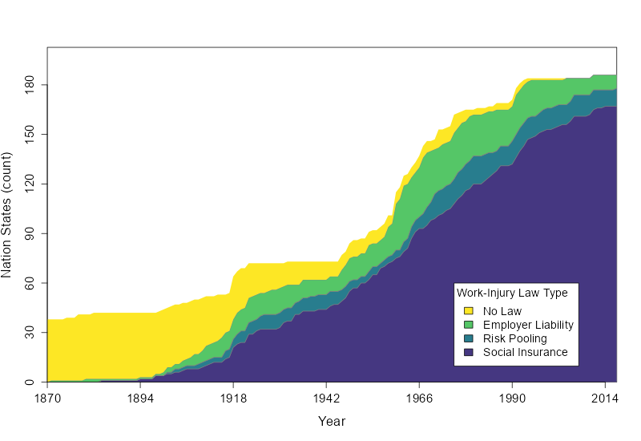

```r
knitr::include_graphics(here::here("results", "Fig_Data_Viz.png"))
```

### Save Data for Analysis

```r
# GDP for
write.csv(wi_df, file = here::here("data", "wi_df.csv"), row.names = F)
# write.csv(wi_df_comb, file = here::here("data","wi_df_comb.csv"), row.names = F)
# write.csv(wi_df_long, file = here::here("data", "wi_df_long.csv"), row.names = F)
```

## References

Bolt, Jutta, Robert Inklaar, Herman de Jong and Jan Luiten van Zanden (2018), “Rebasing ‘Maddison’: new income comparisons and the shape of long-run economic development”, Maddison Project Working paper 10

Breznau, Nate, and Felix Lanver. 2020. Global Work-Injury Policy Database (GWIP): Project Overview and Codebook. 4. Bremen, Germany: Collaborative Research Center SFB 1342 “The Global Dynamics of Social Policy.”

Dahlberg, Stefan, Sören Holmberg, Bo Rothstein, Natalia Alvarado Pachon, and Sofia Axelsson. 2020. The Quality of Government Basic Dataset, Version Jan20. Sweden: University of Gothenburg: The Quality of Government Institute. http://www.qog.pol.gu.se doi:10.18157/qogbasjan20

Rosling, Ola. 2020. “Year of Legal Slavery Abolition”. Gapminder.org, gapm.io/d_lslave_v1 https://www.gapminder.org/data/documentation/legal-slavery/ file downloaded 24-04-2020